# Are Financial Market Returns Normal? What Breaks When You Assume They Are

## 6 Autocorrelation of Returns

An iid assumption implies no autocorrelation at any lag, for the raw returns or for their magnitude: today’s return should carry no statistical information about tomorrow’s. This section tests both directly. The Ljung-Box test (Ljung and Box 1978) checks a series for autocorrelation jointly across a block of lags rather than one lag at a time.

**NoteWhat is the Ljung-Box test?**

The Ljung-Box test checks whether a series has any autocorrelation across a block of lags at once, rather than testing each lag separately, which avoids inflating the false-positive rate that would come from running many single-lag tests side by side. The statistic is

$$Q = n(n+2) \sum_{k=1}^{h} \frac{\hat{\rho}_k^2}{n-k}$$

where $n$ is the sample size, $h$ is the number of lags tested (10 in this report), and $\hat{\rho}_k$ is the sample autocorrelation at lag $k$. $Q$ is compared against a chi-square distribution with $h$ degrees of freedom; a large $Q$ and small p-value reject the null that all $h$ autocorrelations are jointly zero.

```python
ljung_box_results = []
for ticker in TICKERS:
    series = returns.loc[returns["ticker"] == ticker, "log_return"]
    lb_raw = acorr_ljungbox(series, lags=[10], return_df=True)
    lb_squared = acorr_ljungbox(series**2, lags=[10], return_df=True)
    ljung_box_results.append({
        "ticker": ticker,
        "raw_statistic": lb_raw["lb_stat"].iloc[0],
        "raw_p": lb_raw["lb_pvalue"].iloc[0],
        "squared_statistic": lb_squared["lb_stat"].iloc[0],
        "squared_p": lb_squared["lb_pvalue"].iloc[0],
    })

ljung_box_table = pd.DataFrame(ljung_box_results)

style_table(ljung_box_table, formats={
    "raw_statistic": "{:.1f}", "raw_p": "{:.4f}",
    "squared_statistic": "{:,.1f}", "squared_p": "{:.4f}",
})
```

Table 6: Ljung-Box test (10 lags) on raw and squared daily log returns

| ticker | raw_statistic | raw_p | squared_statistic | squared_p |
| --- | --- | --- | --- | --- |
| SPY | 164.6 | 0.0000 | 3,916.4 | 0.0000 |
| AAPL | 49.5 | 0.0000 | 867.5 | 0.0000 |
| MSFT | 88.3 | 0.0000 | 951.9 | 0.0000 |
| JPM | 92.1 | 0.0000 | 2,761.1 | 0.0000 |
| XOM | 30.4 | 0.0007 | 2,433.0 | 0.0000 |
| JNJ | 43.0 | 0.0000 | 2,346.2 | 0.0000 |
| KO | 41.8 | 0.0000 | 3,057.9 | 0.0000 |
| TSLA | 6.2 | 0.7968 | 258.1 | 0.0000 |

Testing 8 tickers against 2 series (raw and squared returns) is 16 tests at once, so the same multiplicity discipline from Section 4 applies: judged against a Bonferroni-adjusted threshold of 0.05 divided by 16, or 0.003125, every squared- return result still rejects independence by many orders of magnitude. The raw-return results are more mixed: 6 of 8 tickers clear even the strict threshold, XOM’s raw p-value of 0.0007 clears 0.003125 as well, and TSLA is the one exception, with a raw p-value of 0.7968 that does not reject independence at any threshold. Even where raw returns are significant, the test statistics are dramatically smaller than their squared-return counterparts, SPY’s 164.6 against 3,916.4, for example, showing that whatever autocorrelation exists in the raw returns is a much weaker effect than the volatility clustering in their magnitude.

The chart below shows why SPY’s raw-return test rejects independence: the ACF and PACF plots of SPY’s raw daily log returns, both against the approximate 95% confidence band a white-noise series would fall inside.

**NoteHow to read an ACF/PACF plot**

Both plots show correlation on the y-axis against lag (in trading days) on the x-axis. The ACF (autocorrelation function) shows the raw correlation between a series and its own value $k$ days earlier, for each lag $k$. The PACF (partial autocorrelation function) shows the same relationship after removing the part already explained by shorter lags, isolating what each additional lag adds on its own. The shaded band marks the approximate 95% confidence interval under the null of no autocorrelation, roughly $\pm 1.96/\sqrt{n}$; a bar extending outside the band is a lag with statistically significant autocorrelation.

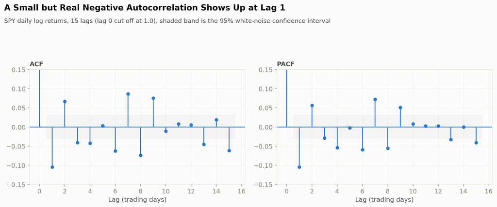

Figure 16: ACF and PACF of SPY daily log returns

```python
fig, axes = plt.subplots(1, 2, figsize=(12, 5))
plot_acf(spy_series, lags=15, ax=axes[0], title=None, color=TICKER_COLORS["SPY"], vlines_kwargs={"colors": TICKER_COLORS["SPY"]})
plot_pacf(spy_series, lags=15, ax=axes[1], title=None, color=TICKER_COLORS["SPY"], vlines_kwargs={"colors": TICKER_COLORS["SPY"]}, method="ywm")
for ax, label in zip(axes, ["ACF", "PACF"]):
    for coll in ax.collections:
        if "Poly" in type(coll).__name__:
            coll.set_facecolor(COLOR_GRID)
    ax.set_title(label, loc="left", fontsize=11, fontweight="bold", color=COLOR_SECONDARY_INK, pad=6)
    ax.set_xlabel("Lag (trading days)")
    ax.set_ylim(-0.15, 0.15)

fig.suptitle("A Small but Real Negative Autocorrelation Shows Up at Lag 1", x=0.01, y=0.99, ha="left", va="top", fontsize=14, fontweight="bold", color=COLOR_PRIMARY_INK)
fig.text(0.01, 0.90, "SPY daily log returns, 15 lags (lag 0 cut off at 1.0), shaded band is the 95% white-noise confidence interval", fontsize=10.5, color=COLOR_SECONDARY_INK)
fig.tight_layout(rect=[0, 0, 1, 0.82])
```

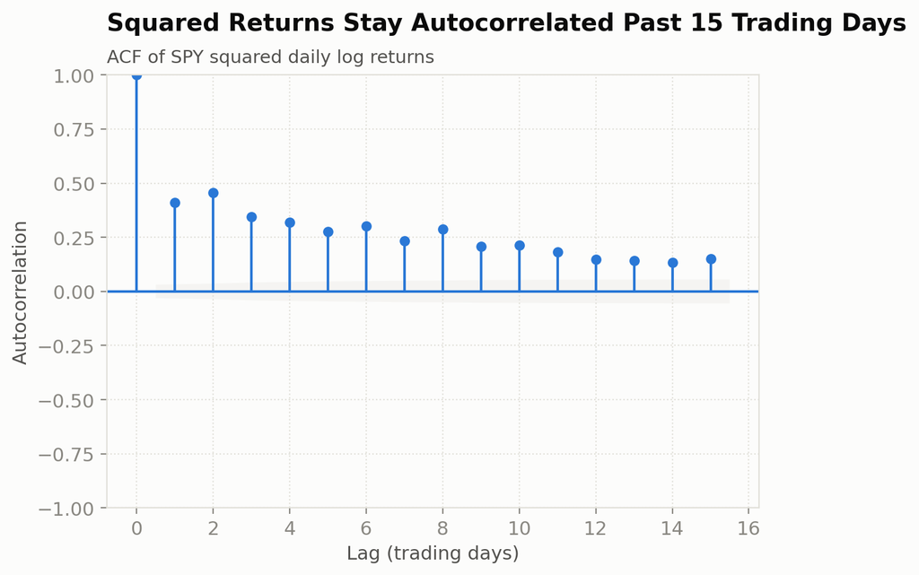

Figure 17: ACF of SPY squared daily log returns

```python
fig, ax = plt.subplots()
plot_acf(spy_series**2, lags=15, ax=ax, title=None, color=TICKER_COLORS["SPY"], vlines_kwargs={"colors": TICKER_COLORS["SPY"]})
for coll in ax.collections:
    if "Poly" in type(coll).__name__:
        coll.set_facecolor(COLOR_GRID)
ax.set_xlabel("Lag (trading days)")
ax.set_ylabel("Autocorrelation")
add_title(ax, "Squared Returns Stay Autocorrelated Past 15 Trading Days", "ACF of SPY squared daily log returns")
fig.tight_layout()
```

Every one of the first 15 lags sits outside the confidence band, starting at 0.41 at lag 1 and still at 0.15 by lag 15, decaying far more slowly than anything in the raw-return ACF. This is the same volatility clustering from Section 5 expressed as an autocorrelation statistic instead of a rolling-window chart: large moves predict more large moves, in either direction, for well over two trading weeks.

The scatter plots below make the ACF’s lag-1 story concrete: SPY’s return against the prior day’s return, and the same comparison using absolute values.

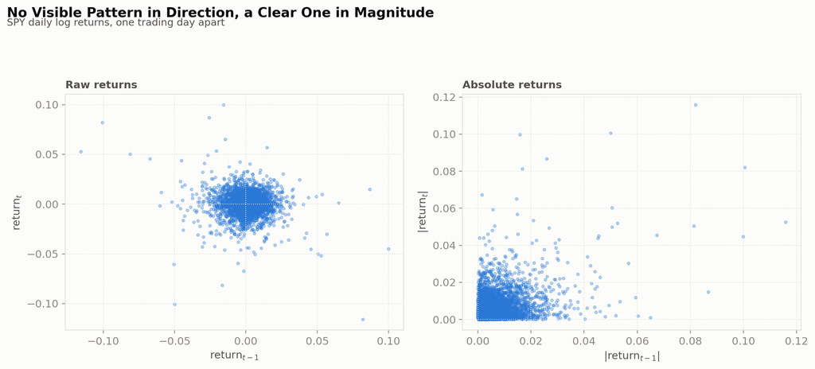

Figure 18: SPY: return_t vs. return_t-1 (left) and |return_t| vs. |return_t-1| (right)

```python
spy_lagged = pd.DataFrame({"return_t": spy_series, "return_t_minus_1": spy_series.shift(1)}).dropna()

fig, axes = plt.subplots(1, 2, figsize=(12, 5.5))
axes[0].scatter(spy_lagged["return_t_minus_1"], spy_lagged["return_t"], s=8, color=TICKER_COLORS["SPY"], alpha=0.3)
axes[0].set_xlabel(r"return$_{t-1}$")
axes[0].set_ylabel(r"return$_t$")
axes[0].set_title("Raw returns", loc="left", fontsize=11, fontweight="bold", color=COLOR_SECONDARY_INK, pad=6)

axes[1].scatter(spy_lagged["return_t_minus_1"].abs(), spy_lagged["return_t"].abs(), s=8, color=TICKER_COLORS["SPY"], alpha=0.3)
axes[1].set_xlabel(r"|return$_{t-1}$|")
axes[1].set_ylabel(r"|return$_t$|")
axes[1].set_title("Absolute returns", loc="left", fontsize=11, fontweight="bold", color=COLOR_SECONDARY_INK, pad=6)

fig.suptitle("No Visible Pattern in Direction, a Clear One in Magnitude", x=0.01, ha="left", fontsize=14, fontweight="bold", color=COLOR_PRIMARY_INK)
fig.text(0.01, 0.93, "SPY daily log returns, one trading day apart", fontsize=10.5, color=COLOR_SECONDARY_INK)
fig.tight_layout(rect=[0, 0, 1, 0.88])
```

The left panel is close to a shapeless cloud, consistent with a weak, easy-to-miss lag-1 effect rather than an obvious visual pattern. The right panel is visibly cone-shaped: points cluster tightly near the origin regardless of the prior day’s size, but the spread of possible same-day moves widens noticeably as the prior day’s move grows, exactly what a positive autocorrelation in magnitude, and nothing equivalent in direction, looks like on a scatter plot.

Finally, the heatmap below summarizes the full Ljung-Box results table as a single image, all 8 tickers against both series.

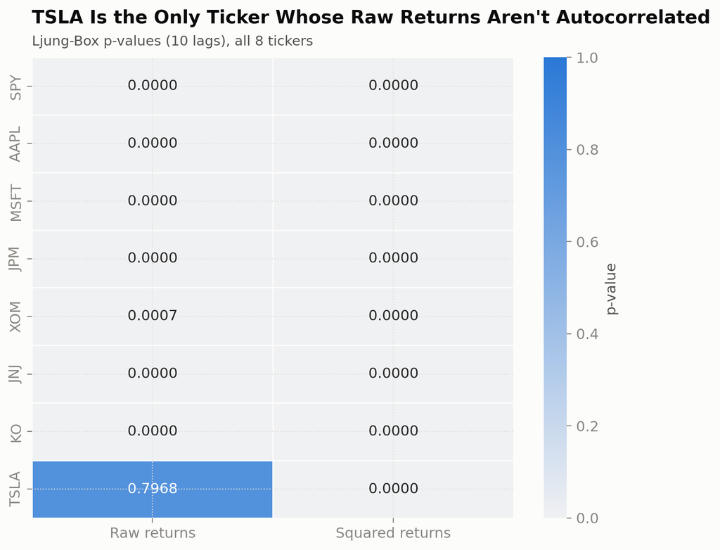

Figure 19: Ljung-Box p-values, all 8 tickers, raw vs. squared returns

```python
ljung_box_pvalues = ljung_box_table.set_index("ticker")[["raw_p", "squared_p"]].reindex(TICKERS)
ljung_box_pvalues.columns = ["Raw returns", "Squared returns"]

fig, ax = plt.subplots(figsize=(7, 6))
sns.heatmap(
    ljung_box_pvalues, annot=True, fmt=".4f", cmap=sns.light_palette(SEQUENTIAL_RAMP[3], as_cmap=True),
    vmin=0, vmax=1, linewidths=1, linecolor=COLOR_SURFACE, cbar_kws={"label": "p-value"}, ax=ax,
)
ax.set_xlabel(None)
ax.set_ylabel(None)
add_title(ax, "TSLA Is the Only Ticker Whose Raw Returns Aren't Autocorrelated", "Ljung-Box p-values (10 lags), all 8 tickers")
fig.tight_layout()
```

TSLA’s raw-return cell is the one visibly light square on the map, a p-value of 0.797 against a column of values under 0.001 everywhere else. Its squared-return cell tells the opposite story: p effectively 0, same as every other ticker. TSLA is the ticker whose day-to-day direction is closest to genuinely unpredictable from its own past, and it is simultaneously as volatility-clustered as anything else in the set, a reminder that “returns are unpredictable” and “volatility is unpredictable” are different claims, and only the second one holds without exception here.

## 7 What This Means for Value-at-Risk

Every section so far has shown a way daily returns depart from an iid-normal assumption: fat tails, volatility that clusters instead of staying constant, and autocorrelation in return magnitude. This section quantifies what that costs a risk model built on the normal assumption, using Value-at-Risk, one of the most common risk measures in finance.

**NoteWhat is Value-at-Risk (VaR)?**

VaR answers one question: how much could a position lose over a given period, with a given confidence level. A 1-day 99% VaR of $20,000 on a $1M position means the model expects a loss larger than $20,000 on no more than 1% of trading days, 1-in-100 days. It says nothing about how large the loss could be on that worst 1%, only where the threshold sits. This report computes VaR two ways: a normal VaR, which assumes returns are normally distributed with the recent sample mean and standard deviation, and a historical (empirical) VaR, which uses the recent sample’s actual worst returns directly, with no distributional assumption at all.

To avoid a subtle problem, testing a VaR method against the exact same data used to calibrate it, both VaR methods here are computed on a rolling basis: each day’s threshold uses only the trailing 252 trading days (about one calendar year) ending the day before, so every breach check is a genuine out-of-sample test, never a threshold looking at its own future.

**Show VaR and backtest functions**

```python
def rolling_var_thresholds(series, alpha, window=252):
    mu = series.rolling(window).mean().shift(1)
    sigma = series.rolling(window).std().shift(1)
    z = stats.norm.ppf(alpha)
    normal_threshold = mu + z * sigma
    historical_threshold = series.rolling(window).quantile(alpha).shift(1)
    return normal_threshold, historical_threshold


def kupiec_pof_test(n, x, p):
    if x == 0:
        lr = -2 * n * np.log(1 - p)
    else:
        phat = x / n
        lr = -2 * (x * np.log(p) + (n - x) * np.log(1 - p) - x * np.log(phat) - (n - x) * np.log(1 - phat))
    return lr, 1 - stats.chi2.cdf(lr, df=1)


def christoffersen_independence_test(breach_series):
    b = breach_series.astype(int).to_numpy()
    n00 = n01 = n10 = n11 = 0
    for i in range(1, len(b)):
        prev, cur = b[i - 1], b[i]
        if prev == 0 and cur == 0:
            n00 += 1
        elif prev == 0 and cur == 1:
            n01 += 1
        elif prev == 1 and cur == 0:
            n10 += 1
        else:
            n11 += 1
    pi01 = n01 / (n00 + n01) if (n00 + n01) > 0 else 0
    pi11 = n11 / (n10 + n11) if (n10 + n11) > 0 else 0
    pi = (n01 + n11) / (n00 + n01 + n10 + n11)

    def safe_log(x):
        return np.log(x) if x > 0 else 0

    ll_restricted = (n01 + n11) * safe_log(pi) + (n00 + n10) * safe_log(1 - pi)
    ll_unrestricted = n00 * safe_log(1 - pi01) + n01 * safe_log(pi01) + n10 * safe_log(1 - pi11) + n11 * safe_log(pi11)
    lr = -2 * (ll_restricted - ll_unrestricted)
    return lr, 1 - stats.chi2.cdf(lr, df=1)
```

The table below runs both VaR methods at both the 95% and 99% confidence levels for SPY, backtests each against SPY’s actual realized returns, and reports the observed breach rate against the nominal rate, alongside Kupiec’s Proportion-of-Failures test (Kupiec 1995) and Christoffersen’s independence test (Christoffersen 1998).

**NoteWhat do Kupiec’s and Christoffersen’s tests check?**

Both tests examine the sequence of breaches (days where the actual loss exceeded the VaR threshold) but check different things. Kupiec’s Proportion-of-Failures test asks whether the *overall rate* of breaches matches the nominal rate the VaR level promises:

$$LR_{POF} = -2 \ln \left( \frac{p^{x} (1-p)^{n-x}}{\hat{p}^{x} (1-\hat{p})^{n-x}} \right)$$

where $n$ is the number of observations, $x$ is the number of breaches, $p$ is the nominal breach rate (0.01 for 99% VaR), and $\hat{p} = x/n$ is the observed rate. $LR_{POF}$ follows a chi-square distribution with 1 degree of freedom; a large value means the observed breach rate is significantly different from what the model promised. Christoffersen’s independence test instead asks whether breaches are *independent over time* rather than clustering together, using the transition counts $n_{ij}$ between consecutive days’ breach/no-breach states:

$$LR_{ind} = -2 \ln \left( \frac{(1-\pi)^{n_{00}+n_{10}} \pi^{n_{01}+n_{11}}}{(1-\pi_{01})^{n_{00}} \pi_{01}^{n_{01}} (1-\pi_{11})^{n_{10}} \pi_{11}^{n_{11}}} \right)$$

where $\pi_{01}$ and $\pi_{11}$ are the probabilities of a breach today given no breach or a breach yesterday, and $\pi$ is the overall breach rate. A model can pass Kupiec (the right average rate) while failing Christoffersen (breaches still arrive in clusters), which is exactly the pattern volatility clustering would predict.

```python
var_backtest_results = []
for level, alpha in [("95%", 0.05), ("99%", 0.01)]:
    normal_thr, hist_thr = rolling_var_thresholds(spy_series, alpha)
    valid = normal_thr.notna()
    actual, normal_thr, hist_thr = spy_series[valid], normal_thr[valid], hist_thr[valid]
    n = len(actual)
    for method, threshold in [("Normal", normal_thr), ("Historical", hist_thr)]:
        breach = actual < threshold
        x = int(breach.sum())
        lr_pof, p_pof = kupiec_pof_test(n, x, alpha)
        lr_ind, p_ind = christoffersen_independence_test(breach)
        var_backtest_results.append({
            "level": level, "method": method, "n": n, "breaches": x,
            "breach_rate": x / n, "nominal_rate": alpha,
            "kupiec_lr": lr_pof, "kupiec_p": p_pof,
            "christoffersen_lr": lr_ind, "christoffersen_p": p_ind,
        })

var_backtest_table = pd.DataFrame(var_backtest_results)

style_table(var_backtest_table, formats={
    "n": "{:,.0f}", "breaches": "{:.0f}",
    "breach_rate": "{:.2%}", "nominal_rate": "{:.0%}",
    "kupiec_lr": "{:.2f}", "kupiec_p": "{:.4f}",
    "christoffersen_lr": "{:.2f}", "christoffersen_p": "{:.4f}",
})
```

Table 7: SPY VaR backtest: 95% and 99%, normal vs. historical, rolling 252-day window

| level | method | n | breaches | breach_rate | nominal_rate | kupiec_lr | kupiec_p | christoffersen_lr | christoffersen_p |
| --- | --- | --- | --- | --- | --- | --- | --- | --- | --- |
| 95% | Normal | 3,699 | 195 | 5.27% | 5% | 0.57 | 0.4522 | 24.27 | 0.0000 |
| 95% | Historical | 3,699 | 182 | 4.92% | 5% | 0.05 | 0.8234 | 30.20 | 0.0000 |
| 99% | Normal | 3,699 | 95 | 2.57% | 1% | 64.12 | 0.0000 | 14.37 | 0.0001 |
| 99% | Historical | 3,699 | 54 | 1.46% | 1% | 6.92 | 0.0085 | 19.67 | 0.0000 |

At 95%, both methods land close to their 5% nominal rate (normal 5.27%, historical 4.92%) and Kupiec does not reject either. At 99%, the picture changes sharply: normal VaR breaches 2.57% of the time against a 1% promise, and Kupiec rejects that gap overwhelmingly (p effectively 0, unaffected by any correction); historical VaR breaches 1.46% of the time, still above nominal but a much smaller miss, and Kupiec rejects more narrowly, at p = 0.0085. This table runs 8 test statistics total (2 methods x 2 levels x {Kupiec, Christoffersen}), and that one result is the single borderline case: judged against a Bonferroni-adjusted threshold of 0.05 divided by 8 (0.00625), historical VaR’s 99% Kupiec rejection does not survive. Every other result in the table is either already non-significant (both 95% Kupiec tests) or significant by many orders of magnitude (everything else), so this correction narrows one specific claim, historical VaR’s 99% calibration is a real but fragile miss, rather than changing the report’s central findings, which rest on the normal-VaR failure and the universal Christoffersen rejections, neither of which is close to the corrected threshold. Christoffersen rejects independence for every method at every level, including the two cases that passed Kupiec: even when the average breach rate looks correct, breaches still cluster in time rather than landing independently, the same volatility-clustering signature from Sections 5 and 6 showing up again, this time inside a risk model’s own failures.

The chart below shows the 99% story directly: SPY’s daily returns against both rolling VaR thresholds, with each method’s breaches marked.

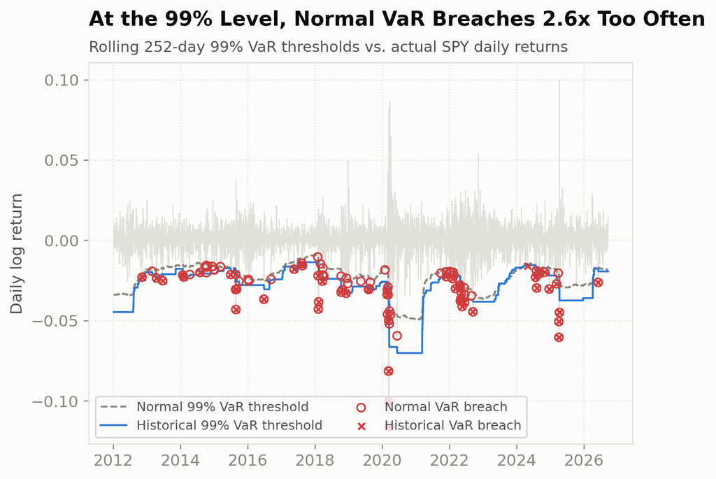

Figure 20: SPY daily returns vs. rolling 99% VaR thresholds, normal and historical

```python
normal_thr_99, hist_thr_99 = rolling_var_thresholds(spy_series, 0.01)
valid_99 = normal_thr_99.notna()
actual_99, normal_thr_99, hist_thr_99 = spy_series[valid_99], normal_thr_99[valid_99], hist_thr_99[valid_99]
normal_breach_99 = actual_99 < normal_thr_99
hist_breach_99 = actual_99 < hist_thr_99

fig, ax = plt.subplots()
ax.plot(actual_99.index, actual_99, color=COLOR_GRID, linewidth=0.7, zorder=1)
ax.plot(normal_thr_99.index, normal_thr_99, color=COLOR_MUTED, linewidth=1.3, linestyle="--", label="Normal 99% VaR threshold", zorder=2)
ax.plot(hist_thr_99.index, hist_thr_99, color=TICKER_COLORS["SPY"], linewidth=1.3, label="Historical 99% VaR threshold", zorder=2)
ax.scatter(actual_99.index[normal_breach_99], actual_99[normal_breach_99], facecolor="none", edgecolor="#d03b3b", linewidth=1.1, s=32, zorder=3, label="Normal VaR breach")
ax.scatter(actual_99.index[hist_breach_99], actual_99[hist_breach_99], color="#d03b3b", s=22, marker="x", linewidth=1.4, zorder=3, label="Historical VaR breach")
ax.set_ylabel("Daily log return")
ax.legend(loc="lower left", ncol=2, fontsize=9)
add_title(ax, "At the 99% Level, Normal VaR Breaches 2.6x Too Often", "Rolling 252-day 99% VaR thresholds vs. actual SPY daily returns")
fig.tight_layout()
```

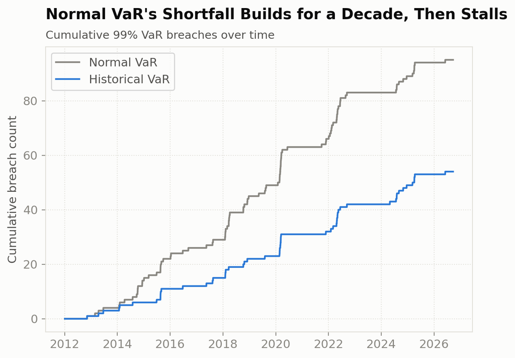

Figure 21: Cumulative 99% VaR breaches over time, normal vs. historical

```python
fig, ax = plt.subplots()
ax.plot(actual_99.index, normal_breach_99.cumsum(), color=COLOR_MUTED, linewidth=1.6, label="Normal VaR")
ax.plot(actual_99.index, hist_breach_99.cumsum(), color=TICKER_COLORS["SPY"], linewidth=1.6, label="Historical VaR")
ax.set_ylabel("Cumulative breach count")
ax.legend(loc="upper left")
add_title(ax, "Normal VaR's Shortfall Builds for a Decade, Then Stalls", "Cumulative 99% VaR breaches over time")
fig.tight_layout()
```

The gap between the two lines opens gradually rather than in one crisis jump: 8 breaches by the end of 2014, 23 by 2018, 41 by the end of 2022, widening in nearly every multi-year stretch along the way rather than sitting flat until a single shock. From 2022 onward, though, the gap holds exactly at 41: both methods add 12 more breaches apiece through the end of the window, tracking each other closely. Normal VaR’s shortfall against historical VaR here is a legacy of the 2011-2022 period specifically, not an ongoing trend, at least not yet.

Is SPY’s 99% normal-VaR overshoot a fluke of one ticker, or does the same failure show up everywhere in the set? The chart below runs the identical rolling backtest on all 8 tickers and plots each method’s actual breach rate as a multiple of the 1% nominal rate.

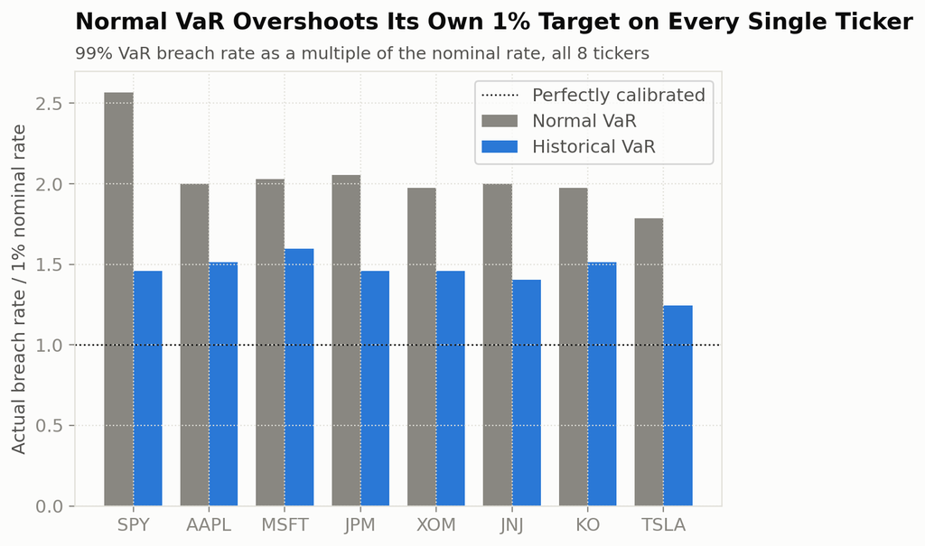

Figure 22: 99% VaR breach rate as a multiple of the 1% nominal rate, all 8 tickers

```python
cross_ticker_var = []
for ticker in TICKERS:
    series = returns.loc[returns["ticker"] == ticker].sort_values("date").set_index("date")["log_return"]
    normal_thr, hist_thr = rolling_var_thresholds(series, 0.01)
    valid = normal_thr.notna()
    actual, normal_thr, hist_thr = series[valid], normal_thr[valid], hist_thr[valid]
    cross_ticker_var.append({
        "ticker": ticker,
        "normal_ratio": (actual < normal_thr).mean() / 0.01,
        "historical_ratio": (actual < hist_thr).mean() / 0.01,
    })
cross_ticker_var = pd.DataFrame(cross_ticker_var)

x_pos = np.arange(len(TICKERS))
width = 0.38

fig, ax = plt.subplots()
ax.bar(x_pos - width / 2, cross_ticker_var["normal_ratio"], width, color=COLOR_MUTED, label="Normal VaR")
ax.bar(x_pos + width / 2, cross_ticker_var["historical_ratio"], width, color=TICKER_COLORS["SPY"], label="Historical VaR")
ax.axhline(1.0, color=COLOR_PRIMARY_INK, linewidth=1, linestyle=":", label="Perfectly calibrated")
ax.set_xticks(x_pos)
ax.set_xticklabels(TICKERS)
ax.set_ylabel("Actual breach rate / 1% nominal rate")
ax.legend(loc="upper right")
add_title(ax, "Normal VaR Overshoots Its Own 1% Target on Every Single Ticker", "99% VaR breach rate as a multiple of the nominal rate, all 8 tickers")
fig.tight_layout()
```

Every normal-VaR bar sits above every historical-VaR bar, and every bar of either color sits above the dotted 1.0 line: no ticker’s 99% VaR is well calibrated by either method, though historical VaR is consistently closer. TSLA has the smallest overshoot on both methods (1.78x and 1.24x), consistent with it also having this report’s lowest excess kurtosis in Section 4.

Averaged across the rolling backtest window, SPY’s normal 99% VaR threshold implies a 1-day loss of $22,921 on a $1M position; the historical 99% VaR threshold implies $28,673, a $5,752 gap, 25% larger than what the normal model reports. A risk desk sizing capital or margin off the normal number alone would be short by roughly a quarter of the loss the data itself says to expect at that confidence level, before even accounting for the breach-clustering problem Christoffersen’s test surfaced above, which affects both methods and means the shortfall is not spread evenly across time but concentrated in exactly the crisis windows, 2020 and 2022, when capital is most needed.

## 8 Practical Implications

This report’s own findings point toward specific fixes, not just problems. A Student-t or skew-t return distribution, with a free parameter for tail thickness, would capture Section 4’s excess kurtosis directly, rather than assuming normality outright and hoping the historical method’s implicit shape happens to compensate. Feeding Section 5’s GARCH(1,1) conditional volatility into VaR instead of a static 252-day rolling window would let the threshold adapt within days of a shock, directly targeting the breach-clustering problem Christoffersen’s test caught above. And because a 252-day window contains only about 2.5 expected exceedances at the 1% level, too few to pin down a tail reliably, which is exactly why even historical VaR under-covered the tail in Section 7, Extreme Value Theory, fitting a Generalized Pareto Distribution to returns beyond a high threshold rather than the whole distribution, is the standard tool built for estimating a thin-sample tail. None of the three is implemented here; each is simply the next step this report’s own diagnostics motivate.

## Appendices

**NoteSession info and full correlation matrix**

| package | version |
| --- | --- |
| python | 3.13.5 |
| yfinance | 1.2.0 |
| pandas | 2.2.3 |
| numpy | 2.1.3 |
| scipy | 1.15.3 |
| statsmodels | 0.14.4 |
| matplotlib | 3.10.0 |
| seaborn | 0.13.2 |
| mplfinance | 0.12.10b0 |
| joypy | 0.2.6 |
| arch | 8.0.0 |

The correlation heatmap in Section 2 rounds every value to two decimals for readability; the full-precision matrix is reproduced below.

| ticker | SPY | AAPL | MSFT | JPM | XOM | JNJ | KO | TSLA |
| --- | --- | --- | --- | --- | --- | --- | --- | --- |
| SPY | 1.0000 | 0.6752 | 0.7281 | 0.7255 | 0.5416 | 0.4917 | 0.5241 | 0.4719 |
| AAPL | 0.6752 | 1.0000 | 0.5525 | 0.3852 | 0.2851 | 0.2904 | 0.3127 | 0.3761 |
| MSFT | 0.7281 | 0.5525 | 1.0000 | 0.4255 | 0.2787 | 0.3012 | 0.3320 | 0.3614 |
| JPM | 0.7255 | 0.3852 | 0.4255 | 1.0000 | 0.5149 | 0.3788 | 0.3990 | 0.2755 |
| XOM | 0.5416 | 0.2851 | 0.2787 | 0.5149 | 1.0000 | 0.3372 | 0.3821 | 0.1679 |
| JNJ | 0.4917 | 0.2904 | 0.3012 | 0.3788 | 0.3372 | 1.0000 | 0.5014 | 0.1023 |
| KO | 0.5241 | 0.3127 | 0.3320 | 0.3990 | 0.3821 | 0.5014 | 1.0000 | 0.1371 |
| TSLA | 0.4719 | 0.3761 | 0.3614 | 0.2755 | 0.1679 | 0.1023 | 0.1371 | 1.0000 |

## References

Anderson, Theodore W., and Donald A. Darling. 1952. “Asymptotic Theory of Certain "Goodness of Fit" Criteria Based on Stochastic Processes.” *The Annals of Mathematical Statistics* 23 (2): 193–212.

Aroussi, Ran. 2024. “yfinance: Download Market Data from Yahoo! Finance’s API.” https://github.com/ranaroussi/yfinance.

Bollerslev, Tim. 1986. “Generalized Autoregressive Conditional Heteroskedasticity.” *Journal of Econometrics* 31 (3): 307–27.

Christoffersen, Peter F. 1998. “Evaluating Interval Forecasts.” *International Economic Review* 39 (4): 841–62.

D’Agostino, Ralph B., and Egon S. Pearson. 1973. “Tests for Departure from Normality. Empirical Results for the Distributions of $b_2$ and $\sqrt{b_1}$.” *Biometrika* 60 (3): 613–22.

Dickey, David A., and Wayne A. Fuller. 1979. “Distribution of the Estimators for Autoregressive Time Series with a Unit Root.” *Journal of the American Statistical Association* 74 (366): 427–31.

Engle, Robert F. 1982. “Autoregressive Conditional Heteroscedasticity with Estimates of the Variance of United Kingdom Inflation.” *Econometrica* 50 (4): 987–1007.

Jarque, Carlos M., and Anil K. Bera. 1980. “Efficient Tests for Normality, Homoscedasticity and Serial Independence of Regression Residuals.” *Economics Letters* 6 (3): 255–59.

Kupiec, Paul H. 1995. “Techniques for Verifying the Accuracy of Risk Measurement Models.” *The Journal of Derivatives* 3 (2): 73–84.

Ljung, Greta M., and George E. P. Box. 1978. “On a Measure of Lack of Fit in Time Series Models.” *Biometrika* 65 (2): 297–303.

Shapiro, Samuel S., and Martin B. Wilk. 1965. “An Analysis of Variance Test for Normality (Complete Samples).” *Biometrika* 52 (3/4): 591–611.